# Method to the Madness

Understanding NCAA Tournament Dynamics Through Data Visualization

The aim of this project is to explore the relationship between public predictions and real outcomes in the NCAA Division 1 Men’s Basketball Tournament. I will be leveraging datasets containing team performance metrics and public pick percentages

Author

Affiliation

Reagan Fleming

School of Information, University of Arizona

## Abstract

This study aims to evaluate the factors that influence public predictions for the 2024 NCAA Men’s Basketball Tournament and identify teams that consistently outperform or underperform their tournament seeding. For the first analysis, public pick percentages for each round will be compared with historical tournament data to determine which factors (if any) have the heaviest influence on public perception. For the second analysis, team performance will be assessed relative to seed expectations using PASE and PASERANK metrics and public picks data to highlight teams that consistently exceed or fall short of expectations. Special attention will be given to the phenomenon of the 12-5 upset. The findings will be visualized to effectively communicate insights into public prediction and team performance trends

## Introduction

This study makes use of 2 data sources. First is NCAA Men’s March Madness, sourced from Nishaan Amin’s Kaggle dataset. This dataset includes historical data for the Men’s College Basketball tournament from 2008 - 2004. The 2 files are team-results.csv and public-picks.csv. Team-results contains statistics from previous tournaments mapped to each team. Stats include wins, losses, Performance Against Seed Expectations, Performance Against Komputer Expectations, amount of times teams made it to each round, and winning percentage. Public-picks contains data about public predictions for the outcome of the 2024 NCAA Tournament. I wound up merging these datasets into one dataframe for analysis.

The first goal of this project is to explore trends and see what factors influence fan predictions. Every year before the tournament, fans fill out brackets which serve as a prediction of what they think the outcome of each game in the tournament will be. Teams are assigned seeds 1-16. Your seed is based on regular season performance. A 1 seed is favored to win, while a 16 seed barely made the tournament and is considered an underdog. In the first round, 1 seeds play 16 seeds, 2 seeds play 15 seeds, 3 plays 14 and so on. This brings me to the second goal of the study, which is to identify which teams have historically outperformed or underperformed expectations and identify upset trends from past tournaments.

## Question 1

Q1: What historical performance factors have the biggest influence on public predictions?

## Question 1 Introduction

My dataset contains data both of team past performance, and fan perception of future performance. From this we can extrapolate what statistical factors fans are looking at when they make their bracket predictions. To accomplish this task we use parts of the dataset that include Win percentage, total wins, total losses, PASE, PAKE, number of Final 4 appearances, and calculated championship likelihood. This analysis highlights the contrast between simple, visible metrics and more advanced and nuanced metrics. Understanding these influences can help analysts and fans predict trends, identify biases, and understand the factors that contribute to the excitement and unpredictability of the March Madness tournament.

## Question 1 Approach

To address this question I used a correlation heatmap. This heatmap visually represents the correlation coefficients between historical performance metrics and public pick percentages for each round of the 2024 tournament. These metrics include Win%, total wins, total losses, PASE, PAKE, Final 4 appearance likelihood (calculated) and championship likelihood (calculated). Each cell in the heatmap displays the correlation coefficient, which indicates the strength and direction of the relationship between that metric and the public’s prediction for the team to win a game in that round. The correlation heatmap is ideal because it provides a comprehensive view of the statistical relationships among multiple variables simultaneously. It allows us to quickly visualize which metrics have the strongest influence on public perception.

## Question 1 Analysis

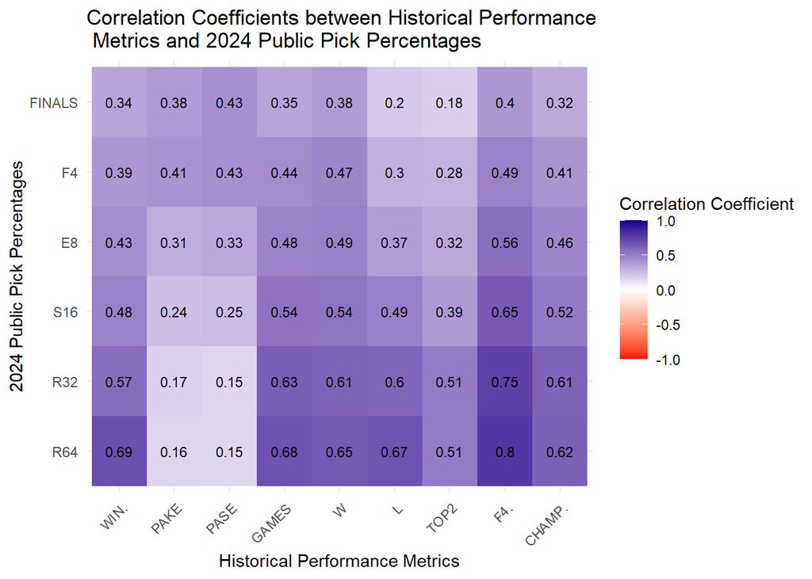

## Question 1 Discussion

The correlation heatmap reveals several trends in the data. We see that Win % and Final 4 percent have very strong correlations in the early rounds (R64 - S16). That correlation wanes in strength toward the later rounds, however. This could indicate that fans are looking at obvious, visible statistics when selecting teams in the early rounds. We can also see that PASE and PAKE have very low correlations in the early rounds, but the correlation grows stronger toward the late rounds (E8-FINALS). While PASE and PAKE can be great indicators of team performance, they aren’t used by fans to select teams in early round games. The increase for PASE and PAKE toward later rounds could be indicative that fans are using them for later rounds, but the correlation still isn’t extremely strong. These findings highlight that public predictions are largely influenced by simpler metrics, particularly in early rounds. Advanced metrics become more significant as the tournament progresses.

## Question 2 Introduction

Q2: Which Men’s College Basketball teams consistently outperform or underperform tournament seeding? Is there any truth to the 12-5 upset narrative?

I wanted to perform analysis to find out which teams consistently perform better, and worse, than the seeders project them to. The team-results.csv file contains data for a statistic called PASE (Performance Against Seed Expectations). PASE measures the difference between how a team is projected to perform and how they actually perform in the tournament. A high PASE value means that a team consistently surpasses expectations and vice versa. Along the same line, I wanted to investigate the statistics behind the narrative of 12-5 upsets. A common piece of advice or “fan wisdom” in March Madness is that in the first round, there will be at least one upset in which a 12 seed team defeats a 5 seed team. For the 12-5 question, I used github user christoukmaji’s MarchMadnessDatasets repo because it contained more specific information regarding team performance in individual games.

## Question 2 Approach

This question is divided into 2 “sub-questions” and necessitated the creation of 2 separate visuals. For the PASE analysis I used a diverging bar chart. I knew that some values would be positive, and some negative. I wanted to show the top 5 overachievers and top 5 underachievers. I decided that a color coded diverging bar chart would be the perfect way to display this information. This would be a very easily digestible way to communicate to the audience which teams constantly overperform, and which ones consistently disappoint.

To investigate any correlation between seeding and upset likelihood, I used a standard bar chart. It shows the winning percentage of teams by seed 9-16. In the tournament, 9 seeds face 8 seeds in the first round (not a huge upset, fairly minor). To the far right side of the bar chart, 16 seeds face 1 seeds in the first round. A 16 seed defeating a 1 seed is a massive upset, and has only happened twice in tournament history (2018 and 2023). We can see in the graph that 9 seeds are around 40% win percentage, 11 seeds are near 50% win percentage, 12 seeds are near 40%, followed by a steep drop off for 13 seeds and below. This shows that there is some truth to the narrative of 12-5 upsets, and that perhaps 11-6 upsets aren’t being talked about enough.

## Question 2 Analysis

[figure not shown]

[figure not shown]

## Question 2 Discussion

This analysis reveals some notable trends in March Madness performance. In the PASE bar chart, we see which teams perform to expectation, and which don’t. Connecticut has the highest PASE ranking, and Texas has the lowest. This divergence underscores the unpredictability of March Madness tournaments and how some teams seem to consistently deliver, while others don’t. A notable fact from this analysis, every team in the Top 5 PASE has won at least 1 National Championship since the year 2000, some (UConn, UNC) have won multiple championships in that timeframe. None of the bottom 5 has won a National Championship since 2000.

The seeding bar chart reveals some interesting trends as well. We would expect to see 9 seeds with the highest win %, and that win % would decrease as the seed increases. That trend does hold in most cases, with 11 seeds and 12 seeds being the outliers. This lends some truth to the narrative of the 12-5 upset and begs the question, why isn’t the 11-6 upset discussed more often? The answer lies in the date range of our data. If you analyze seasons back to 1985, 12-5 upsets do become more common. However, most casual fans have short term memory, and aren’t considering tournaments that occurred when 8 track tapes were still around.

## Notable “side notes”:

Utah State - this team follows both trends that were investigated in question 2. They have been assigned a 12 seed 5 times since 1985, more than any other team. In those games, they are 1-4 against 5 seeds. They are also in the bottom 5 PASE ranking. Perhaps fans are choosing them as the 12-5 upset and their PASE rank decreases because they can’t pull it off.

Purdue - also a bottom 5 team in PASE rank. Purdue had an excellent 2024 regular season, and were predicted to win the championship by approximately 10% of fans. Perhaps this one outlier effected the correlation between PASE and fans predicting that team to win in the finals.

To conclude, this study answered some questions, and raised even more!